# MAT150 - Summer 2023

Phd. Anabela Romina Turlione

Digipen, Bilbao

# The Chain Rule

Suppose you are asked to differentiate the function

\begin{equation} F(x) = \sqrt{x^2+1} \end{equation}

The differentiation formulas you learned in the previous sections do not enable you to calculate $F'(x)$.

## THE CHAIN RULE

If $g$ is differentiable at $x$ and $f$ is differentiable at $g(x)$, then the composite function $F = f\circ g$ defined by $F(x)=f\big(g(x)\big)$ is differentiable at $x$ and is given by the product

\begin{equation} F'(x) = f'\big(g(x)\big)\cdot g'(x) \end{equation}

In Leibniz notation,

\begin{equation} \frac{dF}{dx} =\frac{df}{dg} \frac{dg}{dx} \end{equation}

**This is one of the most important of the differentiation rules.**

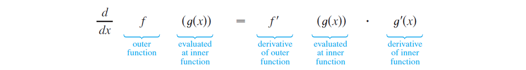

**Exercise 1: Explicit differentiation**

a. Find $f'(x)$, given $f(x)=\big(x^3+x^2\big)^{13}$

b. Find $F'(x)$, where $F(x)=f(x)+x^3 f^2(x)$

c. Find $\frac{dy}{dx}$, given $y=\sqrt{\ln\big(x^2+1\big)}$

d. Find $f'(x)$, given $f(x)=\sin ^3\big(x^4\big)$

e. Find $f'(x)$, given $f(x)=2^{10 x}\cos (x^2+1)$

f. Find $f'(x)$, given

\begin{equation} f(x)= \frac{\tan(x^2+1)}{\ln(\sin x)} \end{equation}

g. If $y = (x^3-x^2+x+1)^3$, and $x = \sin(t)\cdot 2^t+\ln(t)\cdot \tan (t)$, find:

1- \begin{equation} \frac{dy}{dx} \end{equation}

2- \begin{equation} \frac{dx}{dt} \end{equation}

3- \begin{equation} \frac{dy}{dt} \end{equation}

**Exercise 2: Implicit differentiation**

a. Given $\sqrt{y}+y=\sin x$, find $\frac{dy}{dx}$

b. Given $x^5+4x^2y^3-y^5=2$, find $\frac{dy}{dx}$

c. Given $\tan(xy)+\sqrt{x+1}\ln y=5^x$, find $\frac{dy}{dx}$

d. Find $f'(x)$, given $f(x)=\arcsin x$

e. Find $f'(x)$, given $f(x)=\arctan x$

**Exercise 3: Logarithmic differentiation**

a. Find $f'(x)$, given $f(x)=x^x$

b. Find $f'(x)$, given $f(x)=(x^3+5x)^{\sin x}$

c. $x^{y+1}=y^{x+1}$ (Final exam spring 2018)

```
(-1.0, 3.0)
```

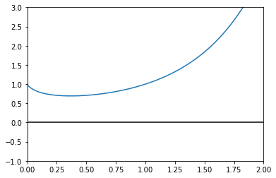

```python
import matplotlib.pyplot as plt
import numpy as np

x=np.linspace(0.0001,2,1000)

plt.plot(x,x**x)
plt.axvline(x = 0, color = 'k')
plt.axhline(y = 0, color = 'k')
plt.xlim(0,2)
plt.ylim(-1,3)
# plt.plot(x,x**x*(np.log(x)+1))
```

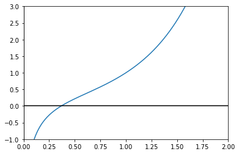

```python
plt.plot(x,x**x*(np.log(x)+1))
plt.xlim(0,2)
plt.ylim(-1,3)
plt.axvline(x = 0, color = 'k')
plt.axhline(y = 0, color = 'k')
```

# Parametric diferentiation

Consider the following parametric equation:

\begin{equation} \left\lbrace \begin{array}{ll} y=F(t) \\ x=x(t) \end{array} \right. \end{equation}

Then, $y=F\big(x(t)\big)$ and

\begin{equation} \frac{dy}{dt}=\frac{dy}{dx}\frac{dx}{dt}\Rightarrow\frac{dy}{dx}=\frac{\frac{dy}{dt}}{\frac{dx}{dt}} \end{equation}

## Example

Given

\begin{equation} \left\lbrace \begin{array}{ll} y=t^2+5 \\ x=e^t \end{array} \right. \end{equation}

- slope on the graph y respect to t:

\begin{equation} \frac{dy}{dt}=2t \end{equation}

- slope on the graph x respect to t:

\begin{equation} \frac{dx}{dt}=e^t \end{equation}

- slope on the graph y respect to x:

\begin{equation} \frac{dy}{dx}=\frac{2t}{e^t} \end{equation}

# The tangent problem in $\Re^2$

Consider the problem of finding the tangent line to a curve $y=f(x)$ at a given point $P (x_0,y_0)$. The equation of a line that crosses the point $P$ is

\begin{equation} y-y_0=m(x-x_0), ~~ where ~~ m=f'(x_0) \end{equation}

## Example

Find the tangent line to the curve $y = x^3-x$ at $x=1/2$.

```
(-1.0, 2.0)
```

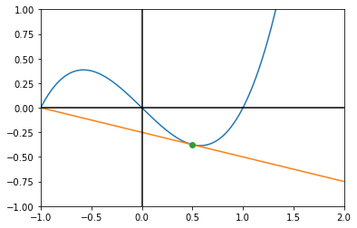

```python
import matplotlib.pyplot as plt
import numpy as np

x=np.linspace(-2,2,1000)

plt.plot(x,x**3-x)
plt.plot(x,-0.25*(x-0.5)-3/8)
plt.plot(0.5,-3/8,'o')
plt.axvline(x = 0, color = 'k')
plt.axhline(y = 0, color = 'k')
plt.ylim(-1,1)
plt.xlim(-1,2)
```

Special cases:

- If the tangent line is horizontal, $m = 0$.
- If the tangent line is vertical, $m = \infty$.
- If two straight lines are parallel, their slope will be the same.
- If two straight lines are normal or perpendicular, their slopes will be related as

\begin{equation} m_1\perp m_2 \Rightarrow m_1 = \frac{-1}{m_2} \end{equation}

**Proof**

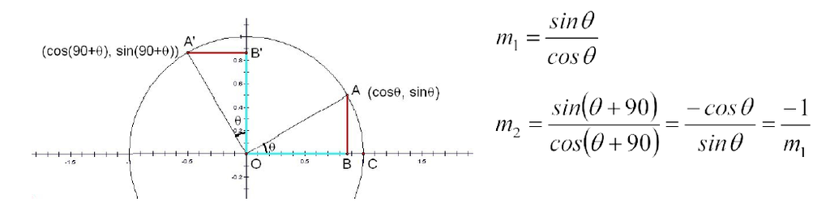

**Exercise 4:**

1. Find the tangent line to the curve $y=x^2-x$ parallel to the line that crosses the points $(1,2)$ and $(3,-4)$.
1. Find a horizontal tangent line to the curve $y=x^2-5x+6$.
1. Find a vertical tangent line to the to the curve $xy+2x=y^2$.
1. Where do the functions $y=\sqrt{x}$ and $y=x^{2/3}$ have a vertical tangent?
2. Find the tangent line to the curve $y=tan x$ perpendicular to the line $y=-x+1$.
3. Find the point where the curves $y=x^3-3x+4$ and $y=3\big(x^2-x\big)$ are tangent to each other; other; that is, they both have a common tangent line in a point in common. (Final spring 2015)
4. For what values of x, does the curve $y=x+2\sin(x)$ have a horizontal tangent?
5. Find the normal line to the circle centered at the origin and radius 5 at $x=3$.
6. Find the normal line to the curve $x^3-\frac{2y}{x^2}+2\sqrt{x}=1$ at $x\ne 0$
7. Find the point where the tangent line to the curve $arcsin(xy)=\frac{\pi}{2}$ is parallel to the line $y=3-x$.
8. Find the tangent line to the curve $y=x^{x^2}$ at $x=1$.
9. The figure shows a lamp located three units to the right of the y-axis and a shadow created by the elliptical region $x^2+4y^2\le 5$. If the point (-5,0) is on the edge of the shadow, how far above the x-axis is the lamp located? (midterm spring 2015 and 2016).

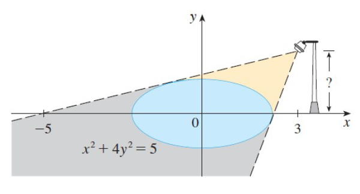

1. Show that there are two tangent lines to the parabola $y=x^2$ that pass through the point $(0,-4)$. Find the coordinates of the points where these tangents lines intersect the parabola.
2. Find the lines that are tangent to both parabolas $y=-1-x^2$ and $y+x^2$ (midterm spring 2013).

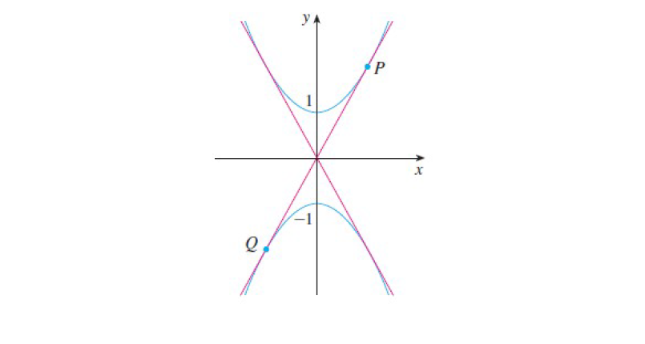

..

```
(-10.0, 6.0)
```

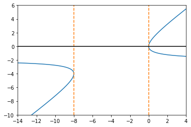

```python
#plor 4-3
import matplotlib.pyplot as plt
import numpy as np

t1=np.linspace(-14,-2.01,1000)
t2=np.linspace(-1.9999,14,1000)

y1=t1
x1=t1**2/(t1+2)

y2=t2
x2=t2**2/(t2+2)

plt.plot(x1,y1, color = 'tab:blue')
plt.plot(x2,y2, color = 'tab:blue')

plt.axvline(x = 0,linestyle = '--', color = 'tab:orange')
plt.axvline(x = -8,linestyle = '--', color = 'tab:orange')
plt.axhline(y = 0, color = 'k')
plt.xlim(-14,4)
plt.ylim(-10,6)
```

```
(-1.0, 4.0)
```

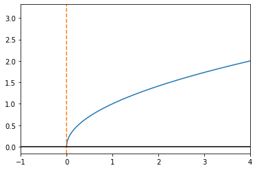

```python
#plot 4-4
import matplotlib.pyplot as plt
import numpy as np

x=np.linspace(0,10,1000)
plt.plot(x,np.sqrt(x), color = 'tab:blue')
plt.axvline(x = 0,linestyle = '--', color = 'tab:orange')
plt.axhline(y = 0, color = 'k')
plt.xlim(-1,4)
```

```
(-1.0, 7.0)
```

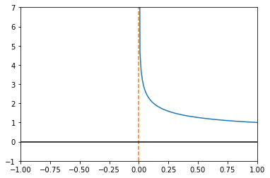

```python
#plot 4-4
import matplotlib.pyplot as plt
import numpy as np

x=np.linspace(0.0001,10,1000)
plt.plot(x,x**(-1/3), color = 'tab:blue')
plt.axvline(x = 0,linestyle = '--', color = 'tab:orange')
plt.axhline(y = 0, color = 'k')
plt.xlim(-1,1)
plt.ylim(-1,7)
```

```python
#plot 4-5
import matplotlib.pyplot as plt
import numpy as np

def plot_4_5():
    x=np.linspace(-np.pi/2+0.001,np.pi/2-0.001,1000)
    plt.plot(x,np.tan(x), color = 'tab:blue')
    plt.plot(x,x, color = 'tab:green',linestyle = '--')
    plt.plot(x,-x+1, color = 'tab:green',linestyle = '--')
    plt.axvline(x = 0,linestyle = '--', color = 'tab:orange')
    plt.axhline(y = 0, color = 'k')
    plt.xlim(-2.5,2.5)
    plt.ylim(-2.5,2.5)
```

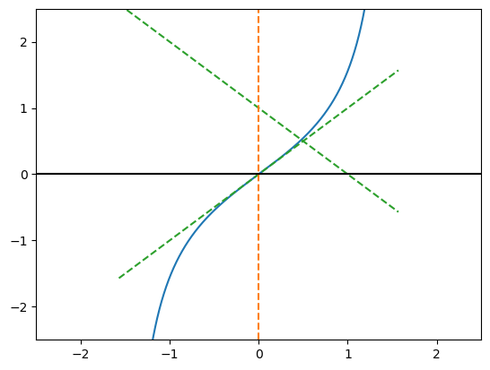

```python
plot_4_5()
```

```python
#plot 4-6
import matplotlib.pyplot as plt
import numpy as np

def plot_4_6():
    x=np.linspace(-2,4)
    plt.plot(x,x**3-3*x+4, color = 'tab:blue')
    plt.plot(x,3*(x**2-x), color = 'tab:blue',linestyle = '--')
    plt.axvline(x = 0, color = 'k')
    plt.axhline(y = 0, color = 'k')
    plt.plot(2,6,'o')
```

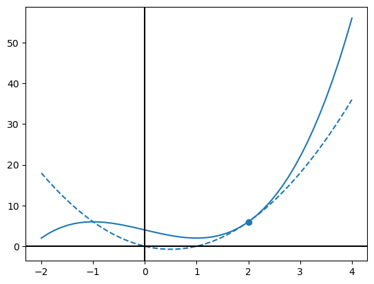

```python
plot_4_6()
```

```python
#plot 4-67
import matplotlib.pyplot as plt
import numpy as np

def plot_4_7():
    H1=[(2/3)*np.pi +i*2*np.pi for i in range(-30,30)]
    H2=[(4/3)*np.pi +i*2*np.pi for i in range(-30,30)]

    x=np.linspace(-20,20,1000)

    plt.plot(x,x+2*np.sin(x), color = 'tab:blue')
    plt.plot(H1,H1+2*np.sin(H1),'o')
    plt.plot(H2,H2+2*np.sin(H2),'o', color = 'tab:blue')
    plt.plot(x,1+2*np.cos(x))

    plt.axvline(x = 0, color = 'k')
    plt.axhline(y = 0, color = 'k')

    plt.axvline(x = 2*np.pi/3, linestyle='--',color = 'tab:orange')
    plt.axvline(x = 4*np.pi/3, linestyle='--',color = 'tab:orange')
    plt.axvline(x = -2*np.pi/3, linestyle='--',color = 'tab:orange')
    plt.axvline(x = -4*np.pi/3, linestyle='--',color = 'tab:orange')
    plt.axvline(x = 2*np.pi/3+2*np.pi, linestyle='--',color = 'tab:orange')

    plt.annotate('$4\pi/3$',xy=(4*np.pi/3+0.1,6), color='tab:orange')
    plt.annotate('$2\pi/3$',xy=(2*np.pi/3+0.1,6), color='tab:orange')
    plt.annotate('$-4\pi/3$',xy=(-4*np.pi/3+0.1,6), color='tab:orange')
    plt.annotate('$-2\pi/3$',xy=(-2*np.pi/3+0.1,6), color='tab:orange')
    plt.annotate('$8\pi/3$',xy=(2*np.pi/3+2*np.pi+0.1,6), color='tab:orange')

    plt.annotate('$dy/dx$',xy=(6,3.5), color='tab:orange')
    plt.annotate('$y$',xy=(6,6.5), color='tab:blue')

    plt.xlim(-5,10)
    plt.ylim(-7,11)
```

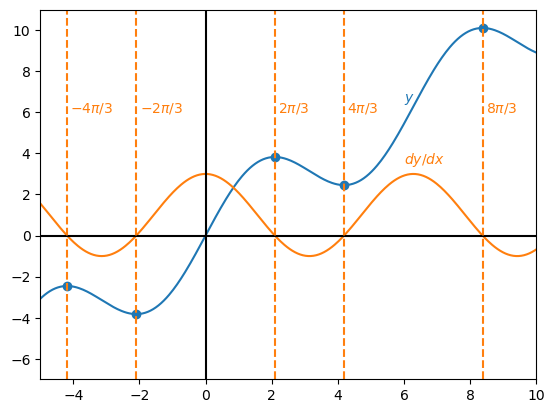

```python
plot_4_7()
```

**Exercise 5:**

a. Find the equation of the tangent line to the curve

\begin{equation} \left\lbrace \begin{array}{ll} x=t+\frac{1}{t}\\ y=t-\frac{1}{t} \end{array} \right. \end{equation}

b. Sketch the three graphs of the curve

\begin{equation} \left\lbrace \begin{array}{ll} x=2\cos t +1\\ y=\sin t -2 \end{array} \right. \end{equation}

and find

\begin{equation} \frac{dx}{dt}~~ \frac{dy}{dt} ~~ and ~~ \frac{dy}{dx} ~~ at ~~ t=\frac{\pi}{3} \end{equation}

c. Write the circle centered at the point $(2,3)$ and radius $R=5$ parametrically and find its slope at $θ=0.5~rad$.

d. Given the helix

\begin{equation} \left\lbrace \begin{array}{ll} x=t\cos t \\ y=t\sin t \end{array} \right. \end{equation}

find

\begin{equation} \frac{dx}{dt}~~ \frac{dy}{dt} ~~ and ~~ \frac{dy}{dx} \end{equation}

e. Given the parametric curve

\begin{equation} \left\lbrace \begin{array}{ll} x=\frac{1}{t-1} \\ y=\ln t \end{array} \right. \end{equation}

Find its horizontal and vertical tangents.

# L'Hopital Rule

Suppose $f$ and $g$ are differentiable and $g'(x)\ne 0$ on an open interval $I$ that contains $a$ (except possibly at $a$). Suppose that

\begin{equation} \lim_{x\to a} f(x) =0 ~~ and ~~ \lim_{x\to a} q(x) =0 \end{equation}

or that

\begin{equation} \lim_{x\to a} f(x) =+\pm \infty ~~ and ~~ \lim_{x\to a} q(x) =+\pm \infty \end{equation}

(In other words, we have an indeterminate form of type $\frac{0}{0}$ or $ \frac{\infty}{\infty} $. Then

\begin{equation} \lim_{x\to a} \frac{f(x)}{g(x)} =\lim_{x\to a} \frac{f'(x)}{g'(x)} \end{equation}

if the limit on the right side exists (or is $\infty$ or $-\infty$).

- **Note 1** L’Hospital’s Rule says that the limit of a quotient of functions is equal to the limit of the quotient of their derivatives, provided that the given conditions are satisfied. It is especially important to verify the conditions regarding the limits of $f$ and $g$ before using l’Hospital’s Rule.
- **Note 2** L’Hospital’s Rule is also valid for one-sided limits and for limits at infinity or negative infinity; that is, $x\to a$” can be replaced by any of the symbols $x\to a^+$, $x\to a^-$, $x\to \infty$, or $x\to -\infty$.
- **Note 3** For the special case in which $f(a)=g(a)=0$, $f'$ and $g'$ are continuous, and $g'(a)\ne 0$, it is easy to see why l’Hospital’s Rule is true. In fact, using the alternative form of the definition of a derivative.

\begin{equation} \lim_{x\to a} \frac{f'(x)}{g'(x)} =\frac{f'(a)}{g'(a)}=\frac{\lim_{x\to a} \frac{f(x)-f(a)}{x-a}}{\lim_{x\to a} \frac{g(x)-g(a)}{x-a}}=\lim_{x\to a}\frac{\frac{f(x)-f(a)}{x-a}}{\frac{g(x)-g(a)}{x-a}}=\lim_{x\to a}\frac{f(x)-f(a)}{g(x)-g(a)}=lim_{x\to a}\frac{f(x)}{g(x)} \end{equation}

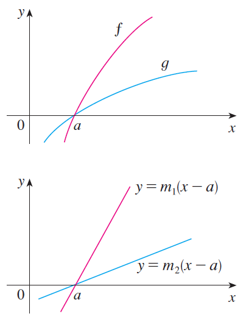

**Exercise 5:**

Evaluate the following using L'Hopital rule.

a.

\begin{equation} \lim_{x\to 2} \frac{x^2-2x}{\ln(x-1)} \end{equation}

b.

\begin{equation} \lim_{x\to \infty} \frac{e^x}{x^2+5x} \end{equation}

c.

\begin{equation} \lim_{x\to 0} \frac{\tan x}{x^2} \end{equation}

d.

\begin{equation} \lim_{x\to 0} \frac{1}{\sin x} - \frac{1}{x} \end{equation}

**Exercise 6:**

More indeterminations: INDETERMINATE POWERS

\begin{equation} \lim_{x\to a} f(x)^{g(x)}=0^0, 1^\infty, \infty^0 \end{equation}

This limits are solved applying logarithms to them in both sides followed by L’Hopital Rule.

a.

\begin{equation} \lim_{x\to \infty} \bigg(\frac{x-4}{x-1}\bigg)^{x-3} \end{equation}

b.

\begin{equation} \lim_{x\to \infty} \bigg(1+\frac{2}{x}\bigg)^{x} \end{equation}

c.

\begin{equation} \lim_{x\to 0^+} \big[1+\sin(4x)\big]^{\cot x} \end{equation}

d.

\begin{equation} \lim_{x\to 0} \cos(2x)^{\csc (x^2)} \end{equation}

e.

\begin{equation} \lim_{x\to 0^-} x^x \end{equation}

f.

\begin{equation} \lim_{x\to \infty} (2x+5)^{\frac{1}{x+1}} \end{equation}

g.

\begin{equation} \lim_{x\to 0} \tan (2x)^x \end{equation}

h.

\begin{equation} \lim_{x\to \infty} (e^x+x)^{1/x} \end{equation}